```r
# Clear all variables
rm(list = ls(all = TRUE))
graphics.off()
```

# **Install & Import Packages**

```r
# install.packages("readr")
# install.packages("HSAUR2")
# install.packages("MVA")
# # Data visualization
# install.packages("ggplot2")
# # LDA model
# install.packages("MASS")
```

```r
library("readr")
library("tools")
library("HSAUR2")
library("MVA")
# Data visualization
library("ggplot2")
# LDA model
library("MASS")
```

# **Load Dataset**

```r
url <- "https://raw.githubusercontent.com/QuantLet/MVA/master/QID-2298-MVAboxbhd/bostonh.dat"

# Read the dataset from the URL and specify column names
df <- read.table(url)

# Rename the columns
col_names <- c()
for (i in 1:ncol(df)) {
  col_names <- c(col_names, paste("x", i, sep = ""))
}
colnames(df) <- col_names

# View the first few rows of the dataset
head(df)
```

```
##        x1 x2   x3 x4    x5    x6   x7     x8 x9 x10  x11    x12  x13  x14
## 1 0.00632 18 2.31  0 0.538 6.575 65.2 4.0900  1 296 15.3 396.90 4.98 24.0
## 2 0.02731  0 7.07  0 0.469 6.421 78.9 4.9671  2 242 17.8 396.90 9.14 21.6
## 3 0.02729  0 7.07  0 0.469 7.185 61.1 4.9671  2 242 17.8 392.83 4.03 34.7
## 4 0.03237  0 2.18  0 0.458 6.998 45.8 6.0622  3 222 18.7 394.63 2.94 33.4
## 5 0.06905  0 2.18  0 0.458 7.147 54.2 6.0622  3 222 18.7 396.90 5.33 36.2
## 6 0.02985  0 2.18  0 0.458 6.430 58.7 6.0622  3 222 18.7 394.12 5.21 28.7
```

- x1 : crim : per capita crime rate by town
- x2 : zn : proportion of residential land zoned for lots over 25,000 sq.ft
- x3 : indus : proportion of non-retail business acres per town
- x4 : chas : Charles River dummy variable (= 1 if tract bounds river; 0 otherwise)
- x5 : nox : nitric oxides concentration (parts per 10 million)
- x6 : rm : average number of rooms per dwelling
- x7 : age : proportion of owner-occupied units built prior to 1940
- x8 : dis : weighted distances to five Boston employment centres
- x9 : rad : index of accessibility to radial highways
- x10: tax : full-value property-tax rate per USD 10,000
- x11 : ptratio : pupil-teacher ratio by town
- x12 : b : $1000(B-0.63)^2$ where B is the proportion of blacks (African American) by town
- x13 : lstat : percentage of lower status of the population
- x14 : medv : median value of owner-occupied homes in USD 1000’s

# **Data Cleaning**

```r
# Check for null values in a dataframe
null_values <- is.na(df)

# Sum the null values in each column
col_null_counts <- colSums(null_values)

# Display the number of null values in each column
print(col_null_counts)
```

```
##  x1  x2  x3  x4  x5  x6  x7  x8  x9 x10 x11 x12 x13 x14
##   0   0   0   0   0   0   0   0   0   0   0   0   0   0
```

```r
# # Remove rows with null values from the dataframe
# df <- na.omit(df)
```

```r
# Check for duplicates in the entire dataframe
duplicates <- duplicated(df)

# Display the rows with duplicate values
print(df[duplicates, ])
```

```
##  [1] x1  x2  x3  x4  x5  x6  x7  x8  x9  x10 x11 x12 x13 x14
## <0 rows> (or 0-length row.names)
```

```r
# # Remove duplicates and keep the first occurrence
# df <- unique(df)
```

# **Preprocessing & EDA**

## Distribusi Data

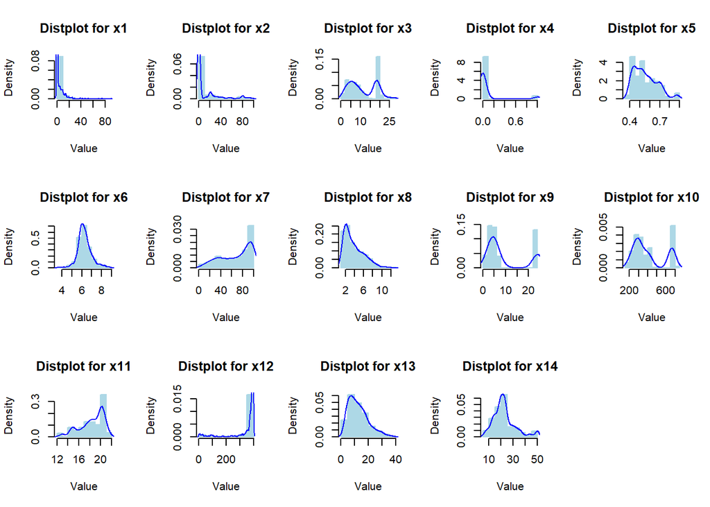

```r
# Path to output pdf
# pdf("D:/bostonhousing_distplot.pdf")

# Set the number of rows and columns for the grid
num_rows <- 3
num_cols <- 5

# Set the plot size
options(repr.plot.width = 10, repr.plot.height = 10)

# Create a 4x3 grid of subplots
par(mfrow = c(num_rows, num_cols))

# Get all numeric columns from the data frame df
numeric_columns <- df[, sapply(df, is.numeric)]

# Loop through the numeric columns and create density plots with histograms
for (i in 1:ncol(numeric_columns)) {
  col_name <- names(numeric_columns)[i]
  col_data <- numeric_columns[, i]

  # Create the histogram
  hist(col_data, col = "lightblue", border = "lightblue", prob = TRUE,
  xlab = "Value", main = paste("Distplot for", col_name))

  # Create the density plot
  density_values <- density(col_data)
  lines(density_values, col = "blue")
}
```

Observasi:

- $x_1 = log(x_1)$
- $x_2 = \frac{x_2}{10}$
- $x_3 = log(x_3)$
- $x_5 = log(x_5)$
- $x_6 = log(x_6)$
- $x_7 = \frac{x{_{7}}^{2.5}}{10000}$
- $x_8 = log(x_8)$
- $x_9 = log(x_9)$
- $x_{10} = log(x_{10})$
- $x_{11} = \frac{{e}^{0.4.x_{11}}}{1000}$
- $x_{12} = \frac{x_{12}}{100}$
- $x_{13} = \sqrt{x_{13}}$
- $x_{14} = log(x_{14})$

Sedangkan $x_4$ akan di-drop karena nilainya binary (kategorikal).

```r
transformed_df <- df

# Perform transformations
transformed_df[, 1] <- log(df[, 1])
transformed_df[, 2] <- df[, 2] / 10
transformed_df[, 3] <- log(df[, 3])
transformed_df[, 5] <- log(df[, 5])
transformed_df[, 6] <- log(df[, 6])
transformed_df[, 7] <- (df[, 7] ^ (2.5)) / 10000
transformed_df[, 8] <- log(df[, 8])
transformed_df[, 9] <- log(df[, 9])
transformed_df[, 10] <- log(df[, 10])
transformed_df[, 11] <- exp(0.4 * df[, 11]) / 1000
transformed_df[, 12] <- df[, 12] / 100
transformed_df[, 13] <- sqrt(df[, 13])
transformed_df[, 14] <- log(as.numeric(df[, 14]))
```

```r
# Drop x4 from df
df = transformed_df
df <- df[, -4]
head(df)
```

```
##          x1  x2        x3         x5       x6       x7       x8        x9
## 1 -5.064036 1.8 0.8372475 -0.6198967 1.883275 3.432567 1.408545 0.0000000
## 2 -3.600502 0.0 1.9558605 -0.7571525 1.859574 5.529585 1.602836 0.6931472
## 3 -3.601235 0.0 1.9558605 -0.7571525 1.971996 2.918119 1.602836 0.6931472
## 4 -3.430523 0.0 0.7793249 -0.7808861 1.945624 1.419592 1.802073 1.0986123
## 5 -2.672924 0.0 0.7793249 -0.7808861 1.966693 2.162710 1.802073 1.0986123
## 6 -3.511570 0.0 0.7793249 -0.7808861 1.860975 2.639947 1.802073 1.0986123
##        x10       x11    x12      x13      x14
## 1 5.690359 0.4548647 3.9690 2.231591 3.178054
## 2 5.488938 1.2364504 3.9690 3.023243 3.072693
## 3 5.488938 1.2364504 3.9283 2.007486 3.546740
## 4 5.402677 1.7722408 3.9463 1.714643 3.508556
## 5 5.402677 1.7722408 3.9690 2.308679 3.589059
## 6 5.402677 1.7722408 3.9412 2.282542 3.356897
```

## Skala Data

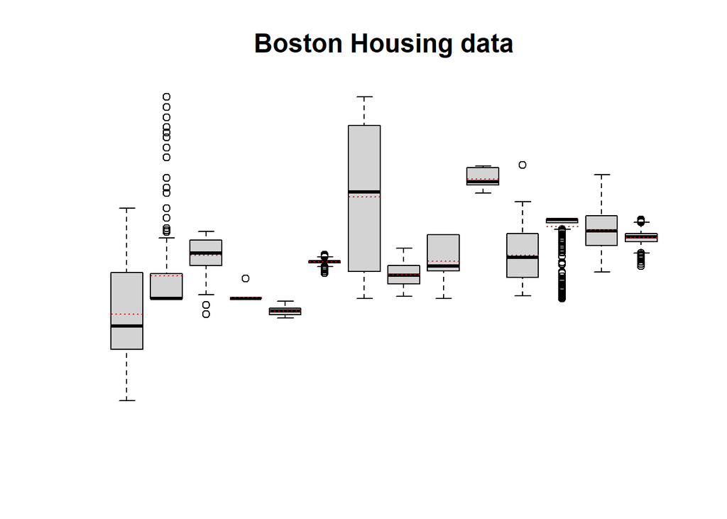

```r
# Boxplot
options(repr.plot.width = 10, repr.plot.height = 10)

boxplot(transformed_df, at = 1:14, axes = FALSE, main = "Boston Housing data", cex.main = 1.5)

for (i in 1:14) {
    lines(c(i - 0.4, i + 0.4), c(mean(transformed_df[, i]), mean(transformed_df[, i])), col = "red3", lty = "dotted",
        lwd = 1.2)
}
```

Observasi:

Variabel-variabel dalam data ini memiliki rentang (skala) yang berbeda-beda. Jika kita tidak menyesuaikan skala ini, maka dapat memengaruhi hasil model machine learning. Oleh karena itu, kita melakukan standardisasi menggunakan z-score (nilai z) untuk membuat semua variabel memiliki skala yang seragam. Ini membantu model machine learning bekerja lebih baik dengan data tersebut.

```r
# Standardization using z-score
standardized_df <- scale(transformed_df)
df <- scale(df)

# Convert to data frame
data <- as.data.frame(standardized_df)
df <- as.data.frame(df)

# transformed_df -> ada x4, sudah ditransformasi
# df -> tidak ada x4, sudah ditansformasi & scaling
# standardized_df -> ada x4, sudah ditransformasi & scaling
```

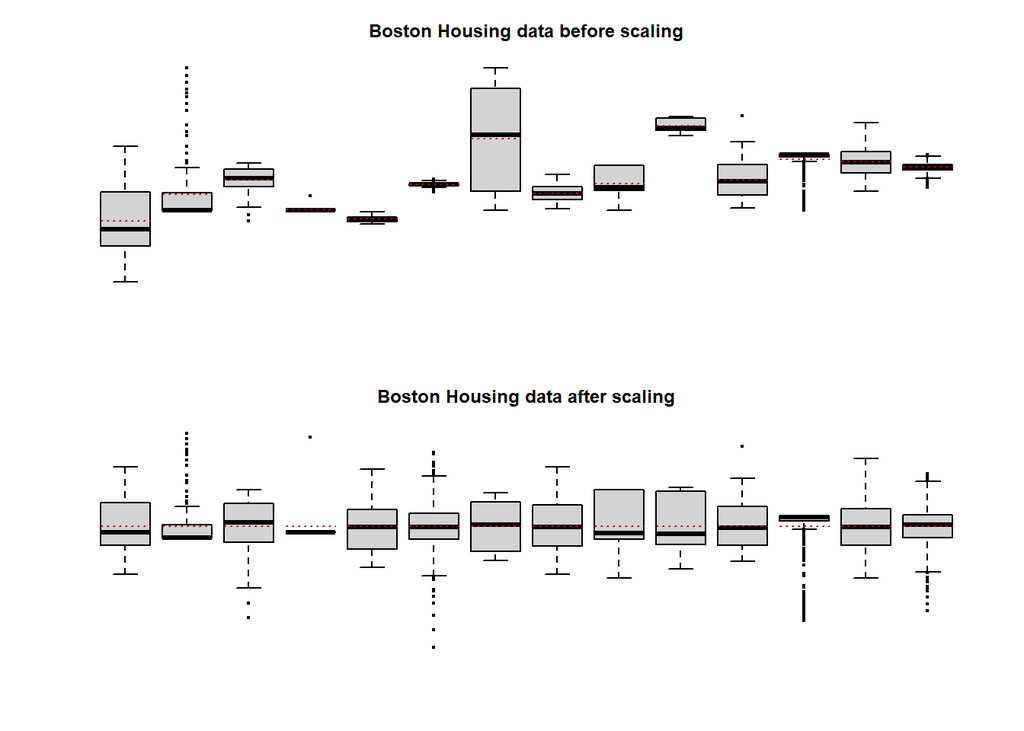

```r
# Before-after scaling visualization
par(mfrow = c(2, 1), ask = FALSE, cex = 0.5)

boxplot(transformed_df, at = 1:14, axes = FALSE, main = "Boston Housing data before scaling", cex.main = 1.5)
for (i in 1:14) {
    lines(c(i - 0.4, i + 0.4), c(mean(transformed_df[, i]), mean(transformed_df[, i])), col = "red3", lty = "dotted",
        lwd = 1.2)
}

boxplot(data, at = 1:14, axes = FALSE, main = "Boston Housing data after scaling", cex.main = 1.5)
for (i in 1:14) {
    lines(c(i - 0.4, i + 0.4), c(mean(data[, i]), mean(data[, i])), col = "red3", lty = "dotted",
        lwd = 1.2)
}
```

# Clustering

```r
d    = dist(df, "euclidean", p = 2)   # euclidean distance matrix
w    = hclust(d, method = "ward.D")   # cluster analysis with ward algorithm
tree = cutree(w, 2)

t1   = subset(df, tree == 1)
t2   = subset(df, tree == 2)
```

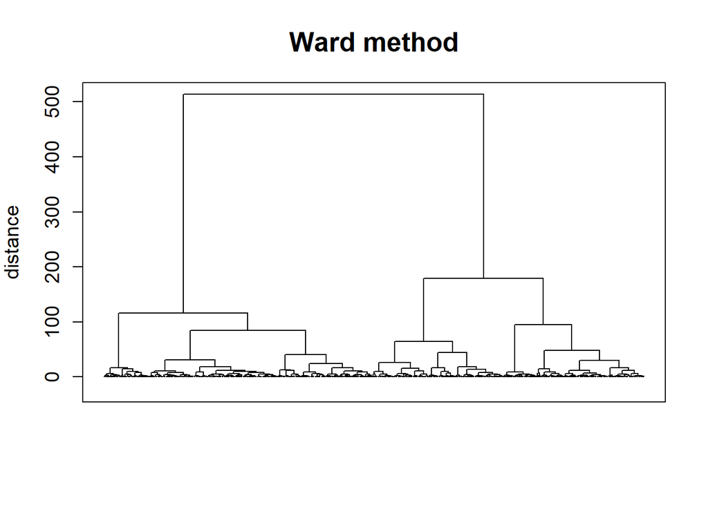

```r
# Dendrogram for df after Ward algorithm
plot(w, hang = -0.1, labels = FALSE, frame.plot = TRUE, ann = FALSE, cex.axis = 1.2)
title(main = "Ward method", ylab = "distance", cex.lab = 1.2, cex.main = 1.6)
```

## Descriptive Statistics of Cluster 1 & Cluster 2

```r
# Count observations in each cluster
cluster_counts <- table(tree)

count_cluster_1 <- cluster_counts[1]
count_cluster_2 <- cluster_counts[2]

print(count_cluster_1)
```

```
##   1
## 251
```

```r
print(count_cluster_2)
```

```
##   2
## 255
```

```r
# Means for Cluster 1 and Cluster 2
mc = cbind(colMeans(subset(df, tree == "1")), colMeans(subset(df, tree == "2")))
mc
```

```
##           [,1]       [,2]
## x1  -0.7098438  0.6987090
## x2   0.4843284 -0.4767311
## x3  -0.7657373  0.7537257
## x5  -0.7664364  0.7544139
## x6   0.4158352 -0.4093123
## x7  -0.7722183  0.7601051
## x8   0.7133298 -0.7021403
## x9  -0.5423774  0.5338695
## x10 -0.6925014  0.6816386
## x11 -0.5458501  0.5372877
## x12  0.3543026 -0.3487449
## x13 -0.6892654  0.6784534
## x14  0.5989634 -0.5895679
```

```r
# Standard deviations for Cluster 1 and Cluster 2
sd_t1 <- sapply(t1[, 1:ncol(df)], sd)
sd_t2 <- sapply(t2[, 1:ncol(df)], sd)

# Combine standard deviations into a matrix
sc <- cbind(sd_t1, sd_t2)
sc
```

```
##         sd_t1      sd_t2
## x1  0.5253670 0.85351149
## x2  1.2437995 0.07445671
## x3  0.8064150 0.44537366
## x5  0.5779648 0.71241729
## x6  0.9041366 0.91898139
## x7  0.6795847 0.60358441
## x8  0.7463883 0.66490241
## x9  0.5666443 1.04657639
## x10 0.4761231 0.90813606
## x11 0.7415761 0.92879842
## x12 0.1269127 1.31384408
## x13 0.6346880 0.81247590
## x14 0.6814040 0.90978615
```

```r
# Means and standard deviations of the 13 standardized variables for Cluster 1
# (251 observations) and Cluster 2 (255 observations)
tbl = cbind(mc[, 1], sc[, 1]/sqrt(nrow(t1)), mc[, 2], sc[, 2]/sqrt(nrow(t2)))
tbl
```

```
##           [,1]        [,2]       [,3]       [,4]
## x1  -0.7098438 0.033160873  0.6987090 0.05344896
## x2   0.4843284 0.078507929 -0.4767311 0.00466266
## x3  -0.7657373 0.050900462  0.7537257 0.02789038
## x5  -0.7664364 0.036480817  0.7544139 0.04461330
## x6   0.4158352 0.057068595 -0.4093123 0.05754885
## x7  -0.7722183 0.042895008  0.7601051 0.03779792
## x8   0.7133298 0.047111609 -0.7021403 0.04163780
## x9  -0.5423774 0.035766269  0.5338695 0.06553916
## x10 -0.6925014 0.030052626  0.6816386 0.05686969
## x11 -0.5458501 0.046807868  0.5372877 0.05816361
## x12  0.3543026 0.008010657 -0.3487449 0.08227611
## x13 -0.6892654 0.040061149  0.6784534 0.05087921
## x14  0.5989634 0.043009842 -0.5895679 0.05697302
```

## Factor Analysis

```r
# Convert to numeric matrix
df <- as.matrix(df)

# spectral decomposition
eig = eigen(cov(df))
eva = eig$values
eve = eig$vectors[, 1:2]

dav = df %*% eve

# Update the 'tr' variable, not 'tree'
tr = tree
tr[tr == 1] = "red"
tr[tr == 2] = "black"
```

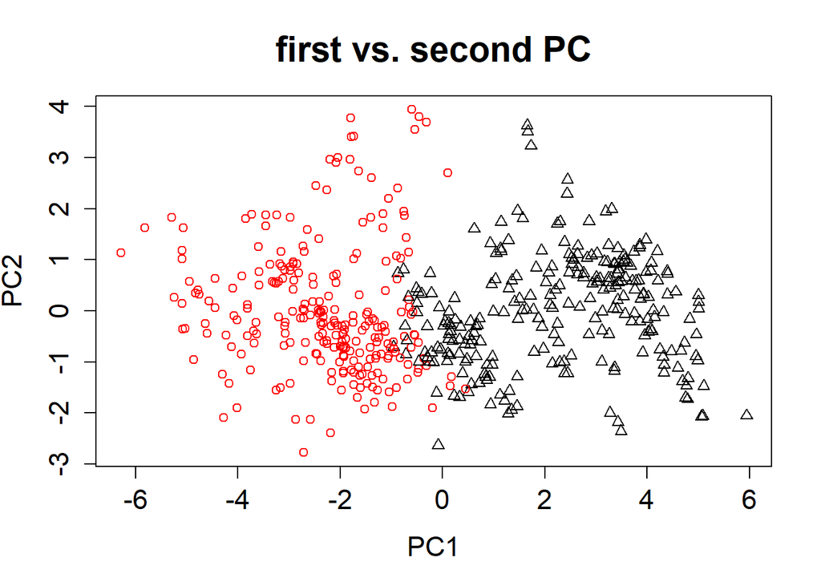

```r
# Scatterplot for the first two PCs displaying the two clusters
plot(dav[, 1], dav[, 2], pch = tree, col = tr, xlab = "PC1", ylab = "PC2", main = "first vs. second PC",
    cex.main = 1.8, cex.axis = 1.4, cex.lab = 1.4)
```

```r
dat = standardized_df
t3 = subset(dat, tree == 1)
t4 = subset(dat, tree == 2)

t = tree
t[t == 1] = "red"
t[t == 2] = "black"
```

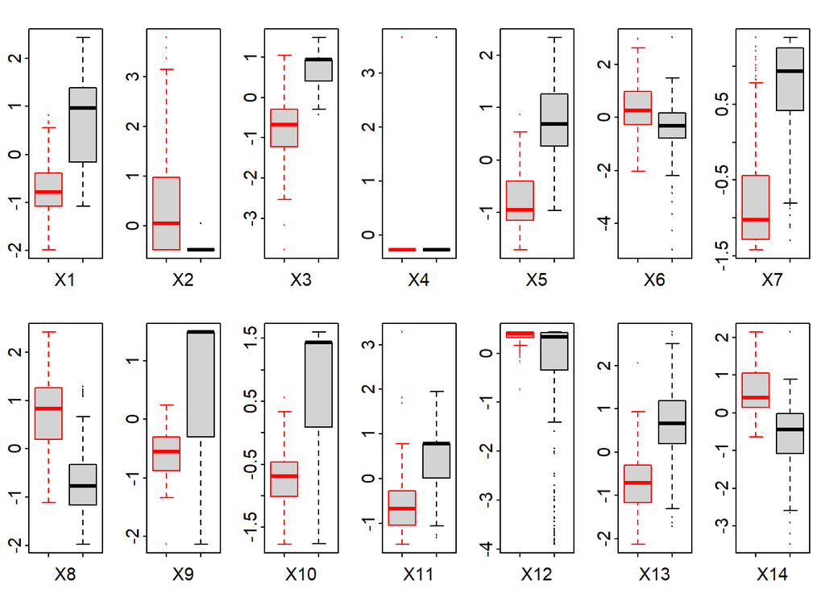

```r
par(mfrow = c(2, 7), cex = 0.3)
boxplot(t3[, 1], t4[, 1], border = c("red", "black"), xlab = "X1", cex.lab = 3, cex.axis = 3)
boxplot(t3[, 2], t4[, 2], border = c("red", "black"), xlab = "X2", cex.lab = 3, cex.axis = 3)
boxplot(t3[, 3], t4[, 3], border = c("red", "black"), xlab = "X3", cex.lab = 3, cex.axis = 3)
boxplot(t3[, 4], t4[, 4], border = c("red", "black"), xlab = "X4", cex.lab = 3, cex.axis = 3)
boxplot(t3[, 5], t4[, 5], border = c("red", "black"), xlab = "X5", cex.lab = 3, cex.axis = 3)
boxplot(t3[, 6], t4[, 6], border = c("red", "black"), xlab = "X6", cex.lab = 3, cex.axis = 3)
boxplot(t3[, 7], t4[, 7], border = c("red", "black"), xlab = "X7", cex.lab = 3, cex.axis = 3)
boxplot(t3[, 8], t4[, 8], border = c("red", "black"), xlab = "X8", cex.lab = 3, cex.axis = 3)
boxplot(t3[, 9], t4[, 9], border = c("red", "black"), xlab = "X9", cex.lab = 3, cex.axis = 3)
boxplot(t3[, 10], t4[, 10], border = c("red", "black"), xlab = "X10", cex.lab = 3,
    cex.axis = 3)
boxplot(t3[, 11], t4[, 11], border = c("red", "black"), xlab = "X11", cex.lab = 3,
    cex.axis = 3)
boxplot(t3[, 12], t4[, 12], border = c("red", "black"), xlab = "X12", cex.lab = 3,
    cex.axis = 3)
boxplot(t3[, 13], t4[, 13], border = c("red", "black"), xlab = "X13", cex.lab = 3,
    cex.axis = 3)
boxplot(t3[, 14], t4[, 14], border = c("red", "black"), xlab = "X14", cex.lab = 3,
    cex.axis = 3)
```

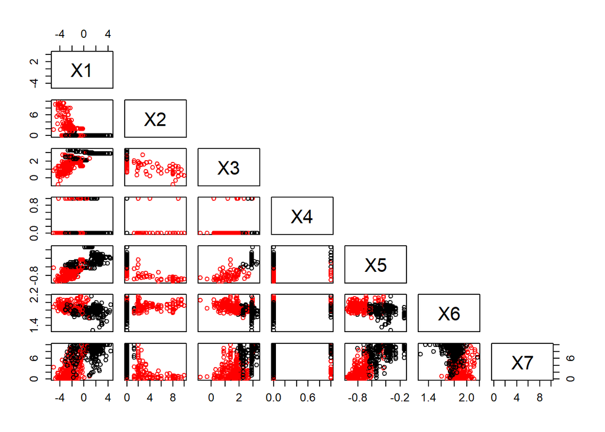

```r
# Scatterplot matrix for variables X1 to X7
pairs(transformed_df[, 1:7], col = tr, upper.panel = NULL, labels = c("X1", "X2", "X3", "X4",
    "X5", "X6", "X7"), cex.axis = 1.2)
```

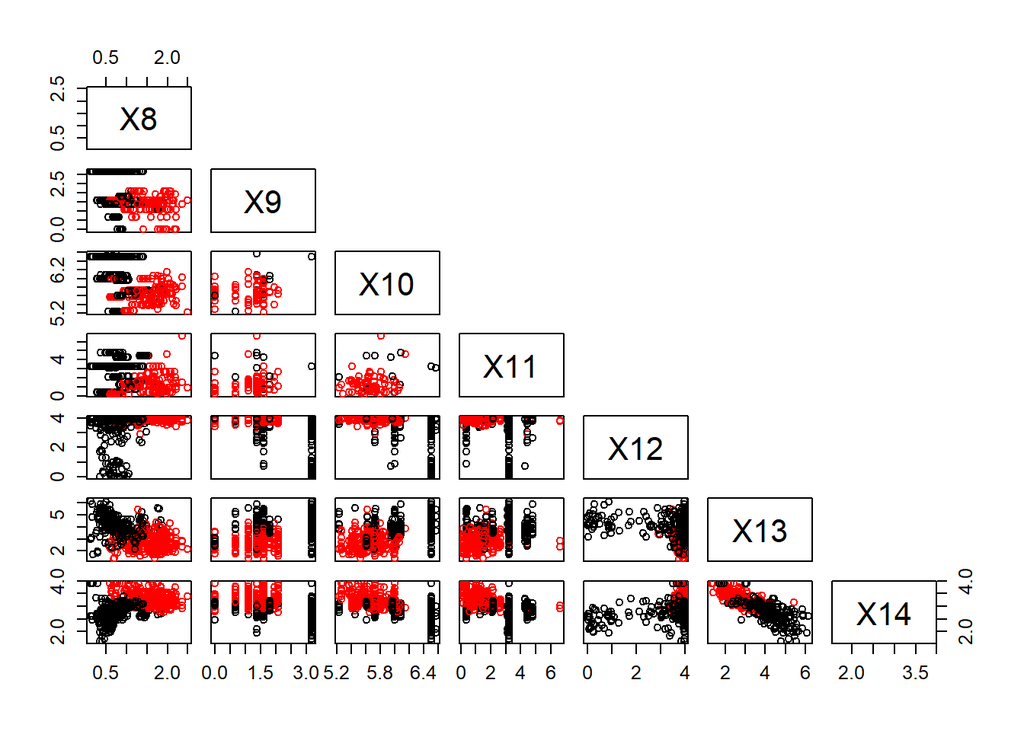

```r
# Scatterplot matrix for variables X8 to X14
pairs(transformed_df[, 8:14], col = tr, upper.panel = NULL, labels = c("X8", "X9", "X10", "X11",
    "X12", "X13", "X14"), cex.axis = 1.2)
```

# Linear Discriminant Analysis

```r
m1  = colMeans(t1) # mean of first cluster
m2  = colMeans(t2) # mean of second cluster
m   = (m1 + m2)/2  # mean of both clusters
# common variance matrix
s = ((nrow(t1) - 1) * cov(t1) + (nrow(t2) - 1) * cov(t2)) / (nrow(transformed_df) - 2)
# alpha for the discrimination rule
alpha = solve(s) %*% (m1 - m2)
```

```r
t1 <- as.matrix(t1)
t2 <- as.matrix(t2)

# APER for clusters of Boston houses
mis1  = sum((t1 - m) %*% alpha < 0)     # misclassified 1
mis2  = sum((t2 - m) %*% alpha > 0)     # misclassified 2
corr1 = sum((t1 - m) %*% alpha > 0)     # correct 1
corr2 = sum((t2 - m) %*% alpha < 0)     # correct 2

# APER (apparent error rate)
aper  = (mis1 + mis2)/nrow(transformed_df)
alph  = (df - matrix(m, nrow(df), ncol(df), byrow = T)) %*% alpha
set.seed(1)
```

```r
# discrimination scores
p = cbind(alph, tree + 0.05 * rnorm(NROW(tree)))

tree2 = tree
tree2[tree2 == 1] = "red"
tree2[tree2 == 2] = "black"
```

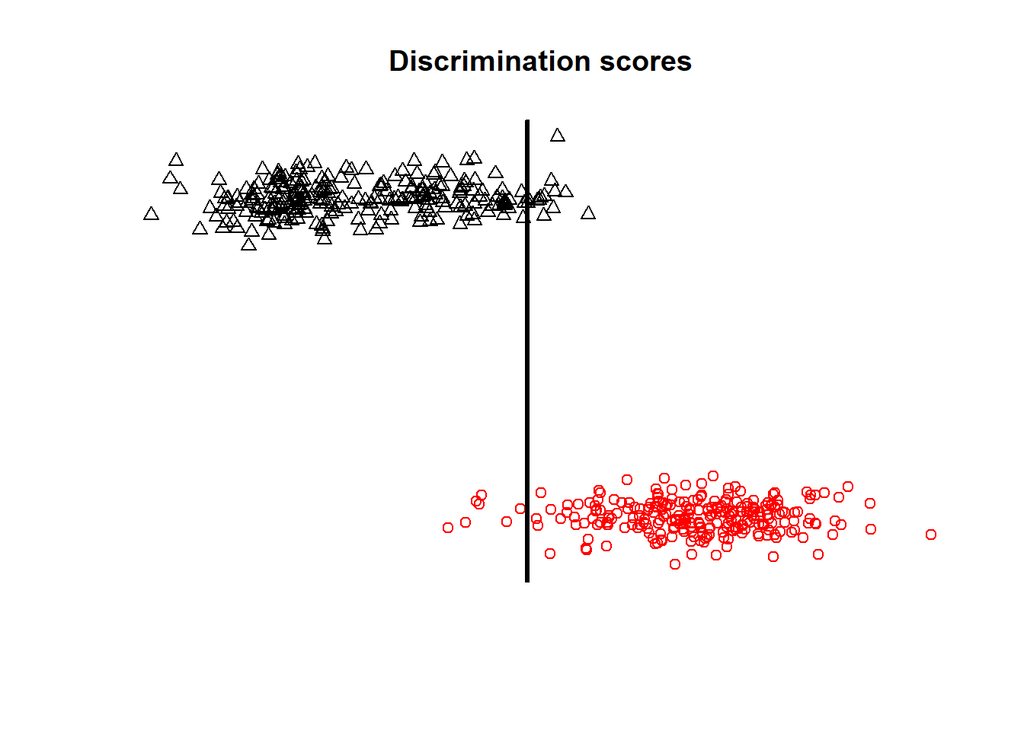

```r
# plot of discrimination scores
plot(p[, 1], p[, 2], pch = tree, col = tree2, xaxt = "n", yaxt = "n", xlab = "", ylab = "",
    bty = "n")
abline(v = 0, lwd = 3)
title(paste("Discrimination scores"))
```

```r
print(aper)
```

```
## [1] 0.03952569
```

```r
data = transformed_df
n = nrow(data)

# AER for clusters of Boston houses
i     = 0
mis1  = 0
mis2  = 0
corr1 = 0
corr2 = 0
while (i < n) {
    i     = i + 1
    xi    = subset(df, 1:n != i)
    treei = subset(tree, 1:n != i)
    t1    = subset(xi, treei == 1)
    t2    = subset(xi, treei == 2)
    m1    = colMeans(t1)                # mean of first cluster
    m2    = colMeans(t2)                # mean of second cluster
    m     = (m1 + m2)/2                 # mean of both clusters
    s     = ((nrow(t1) - 1) * cov(t1) + (nrow(t2) - 1) * cov(t2))/(nrow(df) - 2)    # common variance matrix
    alpha = solve(s) %*% (m1 - m2)                                                  # alpha for the discrimination rule
    mis1  = mis1 + (tree[i] == 1) * ((df[i, ] - m) %*% alpha < 0)                   # misclassified 1
    mis2  = mis2 + (tree[i] == 2) * ((df[i, ] - m) %*% alpha > 0)                   # misclassified 2
    corr1 = corr1 + (tree[i] == 1) * ((df[i, ] - m) %*% alpha > 0)                  # correct 1
    corr2 = corr2 + (tree[i] == 2) * ((df[i, ] - m) %*% alpha < 0)                  # correct 2
}

aer = (mis1 + mis2)/nrow(df)            # AER (actual error rate)
print(aer)
```

```
##            [,1]
## [1,] 0.04150198
```